# Contributing to R packages on GitHub

Author

Kim Dill-McFarland

Published

November 20, 2024

# Overview

This document covers our process for contributing to R packages on GitHub. It assumes working knowledge of R and git.

# 0. Setup

## Software

This pipeline should be completed in [R](https://cran.r-project.org/) and [RStudio](https://posit.co/download/rstudio-desktop/). You should also install the following packages.

```r
#CRAN packages
install.packages(c("devtools", "roxygen2", "renv"))
```

And load them into your current R session.

```r
library(devtools)
library(roxygen2)
library(renv)
```

# 1. Copy the package repo

## 1.1 If you are a member of our organization

As a member of UWISDOM (formerly BIGslu), you may have write privileges to the package repo. If you do, you will create a new repo `branch` for your edits. Then, clone the repo to your local computer and switch to your branch in your git software of choice.

If you need write privileges, contact Kim.

## 1.2 If you are an outside contributer

As an outside member, you do not have write privileges to our GitHub repos. Thus, you need to make `fork` of the package repo e.g. create a copy of the repo under your GitHub account. Then, clone your repo `fork` to your local computer.

# 2. Make changes to the repo

## 2.1 Add a new function

### 2.1.1 Gather your information

Prior to incorporating your function into an existing package, you must have a working function. This must include:

- R script with the function
- Text describing each parameter, its options, and its default
- Test data, either a minimal reproducible example or using example data

### 2.1.2. Create a script for your function within the package

Open the `Rproject` within the package repo. Create a script for your function using `usethis` functionality. The name of this file must be the same as the name of you function.

```r
use_r("my_fxn")
```

```
✔ Setting active project to
  "/Users/kadm/Documents/GitHub/BIGslu/R_packages/testPackage".
☐ Modify R/my_fxn.R.
```

Copy-paste your function into this script. Do not include any example data, test code, etc. Just the function. For example,

```r
my_fxn <- function(language = "english"){
  if(language == "english"){ print("Hello!") }
  if(language == "spanish"){ print("Hola!") }
  if(language == "french"){ print("Bonjour!") }
}
```

Save the script.

### 2.1.3 Declare and update packages

Within your function script, you need to explicitly declare every non-base R package function. For example, `dplyr::select( )`. We do not usually code like this because we have `library` load packages. So go through your function and add package calls as needed.

If you use a new package, add it to the package dependencies like so.

```r
use_package("PACKAGE_NAME")
```

### 2.1.4 Create a `roxygen` header

Place you cursor within your function. Go to the top menu Code > Insert Roxygen skeleton.

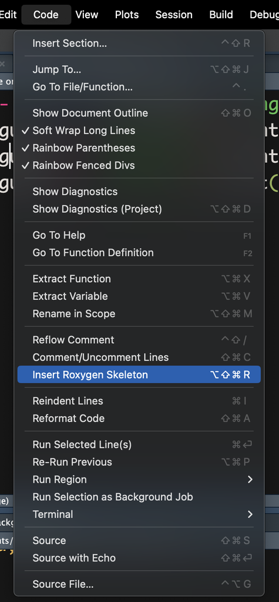

You will see a skeleton in your R function.

```
#' Title
#'
#' @param language
#'
#' @return
#' @export
#'
#' @examples
```

Based on your function, fill out the title, param, and export options. Parameters should be given in the form `@param param_nam Parm class, description. Default.` Include any necessary requirements in the description. For example,

```
#' Print hello in various languages
#'
#' @param language Character string of language to use. Must be lowercase. Default is 'english'
#'
#' @return Character string
#' @export
#'
#' @examples
```

### 2.1.5 Create examples

Using minimal reproducible data or even better, example data from within the package, write the simplest possible example for your function. Please use full parameter names in examples for clarity. For example,

```
#' @examples
#' my_fxn(language = "english")
```

If desired, add additional examples to showcase different settings.

### 2.1.6 Create documentation

Using `devtools`, load all the functions in the package.

```r
load_all()
```

```
ℹ Loading testPackage
```

Then, create/update documentation for functions.

```r
document()
```

```
ℹ Updating testPackage documentation
ℹ Loading testPackage
Writing NAMESPACE
```

## 2.2 Modify an existing function

### 2.2.1 Make changes to the function

Open the `Rproject` within the package repo. Open the script in the `R/` directory for the function you want to edit. Make the necessary changes, and be sure to update the `roxygen` header and examples if parameters are altered.

### 2.2.2 Declare and update packages

Within the function, you need to explicitly declare every non-base R package function. For example, `dplyr::select( )`. We do not usually code like this because we have `library` load packages. So go through your edits and add package calls as needed.

If you use a new package, add it to the package dependencies like so.

```r
use_package("PACKAGE_NAME")
```

### 2.2.3 Update documenation

Using `devtools`, load all the functions in the package.

```r
load_all()
```

```
ℹ Loading testPackage
```

Then, update documentation for functions.

```r
document()
```

```
ℹ Updating testPackage documentation
ℹ Loading testPackage
Writing NAMESPACE
```

### 2.2.4 Check dependencies

If your edits impact outputs used in other packages, like `kmFit` results used in `BIGpicture`, load that dependent package using `library` and check that examples for the relevant functions run without error using the new outputs.

## 2.3 Add example data

### 2.3.1 Create example data

The `usethis` package has a number of functions to codify data in packages. To create your example data, run the following function in the R package project.

```r
use_data_raw()
```

This creates/opens `data-raw/DATASET.R` where you can perform any coding needed to create, modify, and save your example data. Users who install this R package do not have access to this directory, so you can treat it as a contained working space. However, the GitHub repo is PUBLIC so assume anything included here is also PUBLIC. Thus, do not include primary or identifiable patient data in any objects.

### 2.3.2 Add new example data

Once you have your final example data, end the `data-raw/DATASET.R` script with the following to save the object to `data/`. Note that you need to modify the call to include your data object name and run this function for each individual data object to be included.

```r
use_data(example.data, overwrite = TRUE)
```

```
✔ Adding R to Depends field in DESCRIPTION.
✔ Creating data/.
✔ Saving "example.data" to "data/example.data.rda".
☐ Document your data (see <https://r-pkgs.org/data.html>).
```

### 2.3.3 Create data documentation

Unfortunately `document` does not automatically create documentation for data. Instead, create an R script in `R/` that is named the same as the data object like `R/example.data.R`. Fill out the information relevant to your example data. The required pieces include docType, name, keywords, and the data set name at the end. For example,

```r
#' testPackage example data
#'
#' @format A data frame with 3 rows and 2 variables:
#' \describe{
#'   \item{x}{integer. Value 1-3}
#'   \item{y}{integer. Value 4-6}
#'   }
#'
#' @source \url{Add_url_here}
#' @references Add citation here
#' @description A small example data frame
#' @docType data
#' @name example.data
#' @keywords datasets
"example.data"
```

Then run `document` to create the help page.

```r
load_all()
document()
```

# 3. Test package build

Once you have completed your additions/edits, run `check` to build and test the package. In general, it is a good idea to run `load_all`, `document`, and `check` all together to make sure everything is up-to-date before check.

```r
load_all()
document()
check()
```

Your goal it to see no errors, warnings, and comments like so.

```
── R CMD check results ───────────────────────────────────── testPackage 0.1.0 ────
Duration: 12.8s

0 errors ✔ | 0 warnings ✔ | 0 notes ✔
```

If you have errors, warnings, or notes, see the final section of this document for common fixes.

# 4. Create a pull request

From your `branch` or `fork`, create a pull request to the `main` branch of the original repo. Tag Kim for review and she will do (or delegate) final checks before merging into the main, public package.

# Common `check` issues

## Errors

### One or more examples fail

Go to the associated function’s R script. Load all current functions with `load_all()` and then try running each line of the example until you recapitulate the error. Modify your examples until they work. Note you may need to load packages with `library` within the examples section if you are using functions outside of base R or the current package.

## Warnings

### Non-standard license specification

Delete you LICENSE file if it exists. Then, run ONE of the following to add a license correctly.

```r
use_mit_license()
use_gpl3_license()
```

### checking dependencies in R code

This warning will list packages not defined as dependencies in your code. Add each as dependency like so.

```r
use_package("PACKAGE_NAME")
```

## Notes

### no visible binding for global variable

This means you reference a variable or object that is not defined within the function itself. This can cause issues if your local and function environments have objects with the same name. To fix this note, set these variables to NULL at the start of your function.

```r
my_fxn <- function(language = "english"){
  SOMETHING <- NULL
  ...
}
```

You can string together multiple variables like so.

```r
SOMETHING <- SOMETHING_ELSE <- NULL
```

### no visible global function definition

This means you use a function that is not defined within the current function’s environment. To fix this note, make sure every time you use a function not in base R, you include the package path. For example,

```r
package::FUNCTION()
```